# Kamień milowy nr 2

```python
import pandas as pd
import numpy as np
import matplotlib.pyplot as plt
import seaborn as sns
from sklearn.feature_selection import VarianceThreshold
from sklearn.decomposition import PCA
from sklearn.cluster import KMeans,AgglomerativeClustering,Birch
from sklearn.mixture import GaussianMixture
from sklearn.manifold import TSNE
from sklearn.metrics import silhouette_score,calinski_harabasz_score
```

## Funkcje pomocniczne

```python
def score_kmeans(df, cluster_num_vector):
    """
    Funkcja zwraca miary wcss odpowiadające wartością k,
    działa dla modelu k-średnich.
    """
    scores = []
    for k in cluster_num_vector:
        md = KMeans(n_clusters = k)
        md.fit(df)
        scr = md.score(df)
        scores.append(-scr)
    return(scores)
```

```python
def plot_k_scores(k_vec, result, xlab, ylab, title):
    """Wizualizacja dowolnej miary względem dowolnego wektora k."""
    plt.plot(k_vec, result, marker='h')
    plt.xticks(np.arange(min(k_vec), max(k_vec)+1, 2))
    plt.title(title)
    plt.xlabel(xlab)
    plt.ylabel(ylab)
    plt.show()

def find_best_k(df, k_vec):
    scr = score_kmeans(df, k_vec)
    plot_k_scores(k_vec, scr, "k", "wcss", "Poszukiwanie optymalnego 'k'")

def plot_scor(df,metric,title):
    scors = []
    for k in range(3,8):
        kmean = KMeans(k)
        label = kmean.fit_predict(df)
        scor = metric(df,label)
        scors.append(scor)
    fig = plt.figure(figsize=(15, 5))
    plt.plot(range(3, 8), scors,marker='h')
    plt.xticks(np.arange(3,8,1))
    plt.grid(True)
    plt.title(title)
    plt.xlabel('Number of clusters')
    plt.ylabel('Variance ratio score')
```

## Wczytanie danych

```python
labels = pd.read_fwf("./UCI_HAR_Dataset/features.txt",header=None)
X_train = pd.read_fwf("./UCI_HAR_Dataset/train/X_train.txt",header=None)
X_train.columns = labels


y_train = pd.read_fwf("./UCI_HAR_Dataset/train/y_train.txt",header=None)
y_train = pd.Series(y_train[0])

X_test = pd.read_fwf("./UCI_HAR_Dataset/test/X_test.txt",header=None)
X_test.columns = labels

y_test = pd.read_fwf("./UCI_HAR_Dataset/test/y_test.txt",header=None)
y_test = pd.Series(y_test[0])

data = pd.concat([X_train,X_test])
y = pd.concat([y_train,y_test])
```

```python
proper = list()
for i in range(len(data.columns)):
    proper.append(data.columns[i][0])
data.columns = proper

data.reset_index(inplace=True,drop=True)
```

## Co już wiemy?

Po przeprowadzonej analizie eksploracyjnej posiadamy następujące informacje o zbiorze danych:

- wszystkie zmienne są typu numerycznego
- zmienne są już przeskalowane
- dane są kompletne
- zbiór składa się z dwóch typów zmiennych (bez i po transformacji Furiera)
- oryginalnie zbiór jest podzielony na 6 klas

Bazując na tych informacjach postaraliśmy się dobrać optymalne podejście do etapu inżynierii zmiennych. Z charakterystyki zbioru wynika, że nie ma potrzeby skalowania zmiennych, kodowania zmiennych kategorycznych czy też uzupełniania braków danych. Spójrzmy jednak na wymiary naszego zbioru danych:

```python
data.shape
```

```
(10299, 561)
```

W zbiorze mamy bardzo dużą liczbę zmiennych. Jak wiemy nie zawsze jest to korzystne ze względu na np. kosztowność obliczeniową i ryzyko nadmiernego dopasowania. Zdecydowaliśmy się zatem skupić na próbie redukcji liczby zmiennych i wstępnym porównaniu 3 modeli klasteryzacji.  
Podejścia redukcji wymiarów:

- PCA (principal component analysis)
- eliminacja zmiennych o niskiej wariancji
- factor analysis (analiza czynnikowa)
- eliminacja mocno skorelowanych zmiennych
- pozostawienie jedynie zmiennych poddanych transformacji Furiera

Algorytmy analizy skupień:

- K-means
- Birch
- Agglomerative clustering

## Ilość klastrów

Z etykiet wiemy że mamy 6 klastrów, ale sprawdźmy jaką liczbę powinniśmy wybrać według metody "łokcia" dla modelu k-means oraz nieprzekształconych w żaden sposób danych.

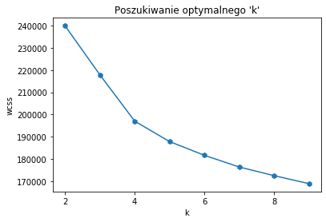

```python
find_best_k(data,range(2,10))
```

## Baseline

Jako punkt odniesniesienia do wszelkich następnych prób weźmy nieprzekształcony w żaden sposób wejściowy zbiór.

```python
data.head()
```

|  | 1 tBodyAcc-mean()-X | 2 tBodyAcc-mean()-Y | 3 tBodyAcc-mean()-Z | 4 tBodyAcc-std()-X | 5 tBodyAcc-std()-Y | 6 tBodyAcc-std()-Z | 7 tBodyAcc-mad()-X | 8 tBodyAcc-mad()-Y | 9 tBodyAcc-mad()-Z | 10 tBodyAcc-max()-X | ... | 552 fBodyBodyGyroJerkMag-meanFre | 553 fBodyBodyGyroJerkMag-skewnes | 554 fBodyBodyGyroJerkMag-kurtosi | 555 angle(tBodyAccMean,gravity) | 556 angle(tBodyAccJerkMean),grav | 557 angle(tBodyGyroMean,gravityM | 558 angle(tBodyGyroJerkMean,grav | 559 angle(X,gravityMean) | 560 angle(Y,gravityMean) | 561 angle(Z,gravityMean) |
| --- | --- | --- | --- | --- | --- | --- | --- | --- | --- | --- | --- | --- | --- | --- | --- | --- | --- | --- | --- | --- | --- |
| 0 | 0.288585 | -0.020294 | -0.132905 | -0.995279 | -0.983111 | -0.913526 | -0.995112 | -0.983185 | -0.923527 | -0.934724 | ... | -0.074323 | -0.298676 | -0.710304 | -0.112754 | 0.030400 | -0.464761 | -0.018446 | -0.841247 | 0.179941 | -0.058627 |
| 1 | 0.278419 | -0.016411 | -0.123520 | -0.998245 | -0.975300 | -0.960322 | -0.998807 | -0.974914 | -0.957686 | -0.943068 | ... | 0.158075 | -0.595051 | -0.861499 | 0.053477 | -0.007435 | -0.732626 | 0.703511 | -0.844788 | 0.180289 | -0.054317 |
| 2 | 0.279653 | -0.019467 | -0.113462 | -0.995380 | -0.967187 | -0.978944 | -0.996520 | -0.963668 | -0.977469 | -0.938692 | ... | 0.414503 | -0.390748 | -0.760104 | -0.118559 | 0.177899 | 0.100699 | 0.808529 | -0.848933 | 0.180637 | -0.049118 |
| 3 | 0.279174 | -0.026201 | -0.123283 | -0.996091 | -0.983403 | -0.990675 | -0.997099 | -0.982750 | -0.989302 | -0.938692 | ... | 0.404573 | -0.117290 | -0.482845 | -0.036788 | -0.012892 | 0.640011 | -0.485366 | -0.848649 | 0.181935 | -0.047663 |
| 4 | 0.276629 | -0.016570 | -0.115362 | -0.998139 | -0.980817 | -0.990482 | -0.998321 | -0.979672 | -0.990441 | -0.942469 | ... | 0.087753 | -0.351471 | -0.699205 | 0.123320 | 0.122542 | 0.693578 | -0.615971 | -0.847865 | 0.185151 | -0.043892 |

5 rows × 561 columns

# Feature engineering

## 1. PCA

Biorąc pod uwagę z jak dużą ilościa kolumn mamy do czynienia nie ma mowy o ręcznym wybieraniu cech, musimy się posiłkować odpowiednimi algorytmami.

```python
pca = PCA(n_components=100)
pca_data = pca.fit_transform(data)
cum_ratio = (np.cumsum(pca.explained_variance_ratio_))

variance_ratio = 0.80
variance = np.cumsum(pca.explained_variance_ratio_)
num = np.sum(variance<variance_ratio)+1
print(f'{variance_ratio} % wariancji jest przestawiane przez {num} zmiennych')
```

```
0.8 % wariancji jest przestawiane przez 11 zmiennych
```

```python
pca = PCA(n_components=11)
df_pca = pca.fit_transform(data)
```

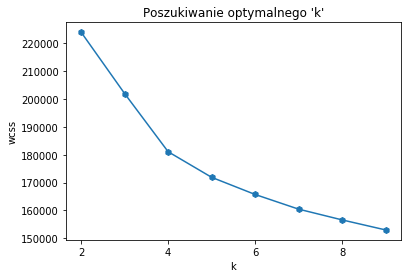

```python
find_best_k(pca_data,range(2,10))
```

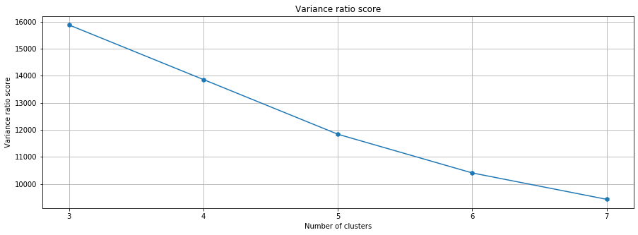

```python
plot_scor(df_pca,calinski_harabasz_score,'Variance ratio score')
```

Natrafiamy na dość spory problem, mianowicie wszystkie miary nagradzają najlepiej modele z małą liczbą klastrów, gdzie wiemy iż nasza prawidłowa ilość klastrów wynosi 6.

### Prawdziwe etykiety

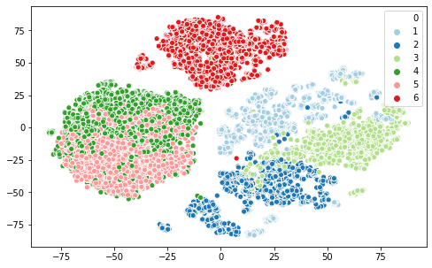

```python
pca = PCA(n_components=0.9, random_state=3)
pca_data = pca.fit_transform(data)

tsne = TSNE(random_state=3)
tsne_transformed = tsne.fit_transform(pca_data)

fig = plt.gcf()
fig.set_size_inches(8,5)
sns.scatterplot(tsne_transformed[:,0],tsne_transformed[:,1],hue=y,palette='Paired')
```

### Etykiety wyznaczane przez algorytm

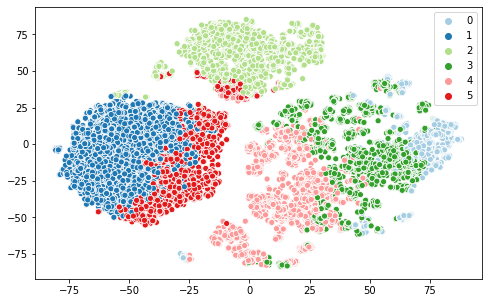

```python
kme = KMeans(6)
label = kme.fit_predict(pca_data)

fig = plt.gcf()
fig.set_size_inches( 8, 5)
sns.scatterplot(tsne_transformed[:,0],tsne_transformed[:,1],hue=label,palette='Paired')
```

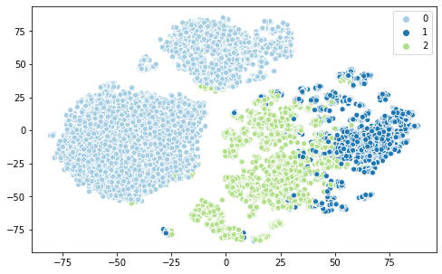

```python
kme = KMeans(3)
label = kme.fit_predict(pca_data)

fig = plt.gcf()
fig.set_size_inches( 8, 5)
sns.scatterplot(tsne_transformed[:,0],tsne_transformed[:,1],hue=label,palette='Paired')
```

## 2. Usuwanie zmiennych z niską wariancją

Kolejną metoda z której zdecydujemy się skorzystać będzie Variance Threshold. Metoda ta polega na odrzucaniu zmiennych z niską wariancją. W tym podejściu zakładamy że odrzucane zmienne nie zawierają informacji, które pozwolą odróżnić klasy.

```python
selector = VarianceThreshold(0.2)
df_var = selector.fit_transform(data)
```

```python
df_var.shape
```

```
(10299, 55)
```

Metoda pozbyła się prawie 500 kolumn, zostawiając te o wariancji powyżej 0.2.

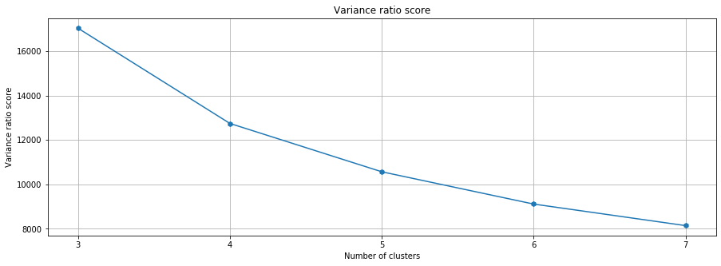

```python
plot_scor(df_var,calinski_harabasz_score,'Variance ratio score')
```

Kolejny raz widzimy iż cięzko bazować na miarach opierających sie na odpowiednim definiować klastrów, bo wynik odbiega od tego co byśmy chieli zobaczyć

## 3. Factor Analysis

Metoda statystyczna, której celem jest opisanie zależności między zaobserwowanymi, skorelowanymi zmiennymi przy pomocy możliwie mniejszej liczby zmiennych nieobserwowanych nazywanych czynnikami bądź faktorami, które są wzajemnie nieskorelowane.

```python
#%pip install factor_analyzer
from factor_analyzer import FactorAnalyzer
```

### Kaiser-Meyer-Olkin test

Test ten mierzy czy zbiór danych jest odpowiedni do przeprowadzenia analizy czynnikowej (factor analysis). KMO przyjmuje wartości od 0 do 1. Wartość powyżej 0.6 oznacza adekwatność użycia metody analizy czynnikowej.

```python
from factor_analyzer.factor_analyzer import calculate_kmo
kmo_all, kmo_model = calculate_kmo(data)
print("Wartość KMO dla naszych danych: {0:4.3f}".format(kmo_model))
```

```
Wartość KMO dla naszych danych: 0.979
```

Jak widzimy nasz zbiór jest perfekcyjnym przypadkiem do analizy czynnikowej.

### Analiza czynnikowa

```python
#Wykonanie analizy czynnikowej
factor_analyzer = FactorAnalyzer(rotation=None, n_factors=561)
factor_analyzer.fit(data)

#Wartości własne
wartosci_wlasne, wektory = factor_analyzer.get_eigenvalues()
```

Jedną z metod wyboru odpowiedniej liczby czynników, jest wybór tych z nich, dla których odpowiadające wartości własne są większe niż 1. Dla naszego zbioru będzie to 63 czynniki. Uzyskujemy więc redukcję liczby zmiennych z 561 do 63.

```python
num_factors = len(wartosci_wlasne[wartosci_wlasne>1])
num_factors
```

```
63
```

Dla mniejszych zbiorów można dokonać doboru liczby czynników metodą graficzną, podobną do metody "łokcia". W naszym przypadku, ciężko jest jednak zastosować tę metodę, gdyż wykres staje się nieczytelny.

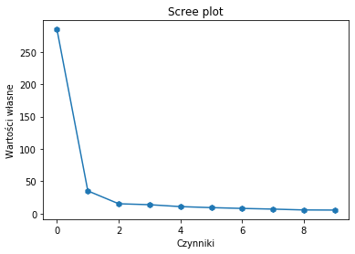

```python
plot_k_scores(range(10), wartosci_wlasne[0:10], "Czynniki", "Wartości własne", "Scree plot")
```

```python
#Analiza dla dobranej liczby czynników
fa = FactorAnalyzer(n_factors=num_factors)
fa.fit(data)
```

```
FactorAnalyzer(bounds=(0.005, 1), impute='median', is_corr_matrix=False,
               method='minres', n_factors=63, rotation='promax',
               rotation_kwargs={}, use_smc=True)
```

```python
#Zbiór danych po transformacji analizy czynników
df_factor = fa.transform(data)
df_factor = pd.DataFrame(df_factor)
```

```python
print("Wymiary zbioru danych po transformacji nr 3:")
print(df_factor.shape)
```

[output not shown]

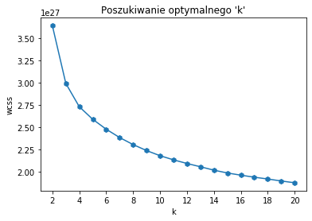

```python
find_best_k(df_factor, range(2, 21))
```

```python
#Zapis do pliku df2, aby uniknąć czasochłonnych obliczeń
df_factor.to_csv("df2.csv")
```

## 4. Usunięcie wysoko skorelowanych zmiennych

W naszym zbiorze danych jest wiele zmiennych bardzo mocno skorelowanych. Rozsądnym podejściem wydaje się próba usunięcia ich ze zbioru. Zdecydowaliśmy się usunąć zmienne o współczynniku korelacji większym niż 0.9.

```python
def remove_corr(dataset, threshold):
    #Zbiór nazw usuniętych kolumn
    col_corr = set()
    corr_matrix = dataset.corr()
    for i in range(len(corr_matrix.columns)):
        for j in range(i):
            if (corr_matrix.iloc[i, j] >= threshold) and (corr_matrix.columns[j] not in col_corr):
                #nazwa kolumny
                colname = corr_matrix.columns[i]
                col_corr.add(colname)
                if colname in dataset.columns:
                    #usunięcie kolumny
                    del dataset[colname]
    return(dataset)
```

```python
df_corr = data.copy()
df_corr = remove_corr(df_corr, 0.9)
```

```python
print("Wymiary zbioru danych po transformacji nr 4:")
df_corr.shape
```

```
Wymiary zbioru danych po transformacji nr 4:
```

```
(10299, 251)
```

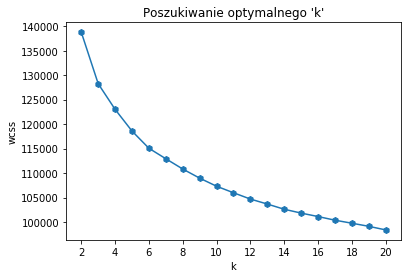

```python
find_best_k(df_corr, range(2, 21))
```

## 5. Tylko zmienne po transformacie Furiera

EDA pokazała, że transformata Furiera poprawiała separowalność klas w przypadkach możliwych do analizy wizualnej. Z tego powodu postanowiliśmy przetestować podejście, polegające na pozostawieniu w zbiorze tylko tych zmiennych, które zostały przez autorów zbioru danych (badania) poddane transformacie Furiera.

```python
df_fourier = data.iloc[:, 266:]
```

```python
print("Wymiary zbioru danych po transformacji nr 5:")
df_fourier.shape
```

```
Wymiary zbioru danych po transformacji nr 5:
```

```
(10299, 295)
```

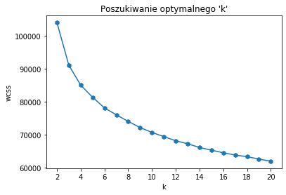

```python
find_best_k(df_fourier, range(2, 21))
```

# Modelowanie

```python
def score_clustering(df, model, k_vec, score_fun):
    """
    Oblicza miary, za pomocą przekazanej funkcji miay,
    względem k, a także przekazanego modelu.
    """
    scores=[]
    for k in k_vec:
        md = model(n_clusters=k)
        labels = md.fit_predict(df)
        score = score_fun(df, labels)
        scores.append(score)
    return(scores)
```

```python
df_factor = pd.read_csv('df2.csv')
datasets = {"orginal": data,
            "df_pca" : df_pca,
            "df_var": df_var,
            "df_factor": df_factor,
            "df_corr": df_corr,
            "df_fourier": df_fourier
            }

models = {"kmeans": KMeans,
          "agg": AgglomerativeClustering,
          "birch": Birch}

optimal_k_6 = {"orginal": 6,
             "df_pca": 6,
             "df_var" : 6,
            "df_fourier": 6,
            "df_corr": 6,
            "df_factor": 6}

optimal_k_3 = {"orginal": 3,
             "df_pca": 3,
             "df_var" : 3,
            "df_fourier": 3,
            "df_corr": 3,
            "df_factor": 3}


def research(datasets, models, optimal_k, score_fun):
    results = pd.DataFrame()

    for df_k in datasets:
        for model_k in models:
            md = models[model_k]()
            df = datasets[df_k]
            k = optimal_k[df_k]

            md.n_clusters = k
            labels = md.fit_predict(X = df)
            score = score_fun(df, labels)
            results.loc[df_k, model_k] = score

            #temp
            print(df_k + model_k)
    return(results)
```

## Wyniki: miara silhouette

```python
silhouette_results_6 = research(datasets, models, optimal_k_6, silhouette_score)
```

```python
silhouette_results_6
```

|  | kmeans | agg | birch |
| --- | --- | --- | --- |
| orginal | 0.132143 | 0.079372 | 0.079372 |
| df_pca | 0.254071 | 0.210469 | 0.201818 |
| df_var | 0.217846 | 0.190949 | 0.206739 |
| df_factor | 0.105811 | 0.215942 | 0.215942 |
| df_corr | 0.083635 | 0.046041 | 0.046041 |
| df_fourier | 0.137708 | 0.116516 | 0.143183 |

```python
silhouette_results_3 = research(datasets, models, optimal_k_3, silhouette_score)
```

```python
silhouette_results_3
```

|  | kmeans | agg | birch |
| --- | --- | --- | --- |
| orginal | 0.324273 | 0.306846 | 0.306846 |
| df_pca | 0.438609 | 0.444234 | 0.445431 |
| df_var | 0.483657 | 0.481741 | 0.481111 |
| df_factor | 0.308297 | 0.279283 | 0.279283 |
| df_corr | 0.174962 | 0.144576 | 0.144576 |
| df_fourier | 0.375957 | 0.356594 | 0.355685 |

## Wnioski

Zgodnie z wcześniejszymi obserwacjami wyższe miary silhouette otrzymujemy dla liczby klastrów równej 3. Bardziej zróżnicowane są obserwacje miar pomiędzy podejściami inżynierii zmiennych oraz wyboru modeli.

### 6 klastrów

Najlepszy wynik:

- k-means na danych z PCA

Ponadto stabilną poprawę wyniku dała metoda elimancji zmiennych o niskiej wariancji. Analiza czynnikowa przyniosła korzyści tylko dla dwóch modeli.

### 3 klastry

Najlepszy wynik i metoda:

- VarianceThreshold, wyniki modeli bardzo zbliżone

Ponadto stabilną, lecz nieco słabszą poprawę dało PCA.

### Na przyszłość

Metody dające dobre rezultaty to:

- PCA
- VarianceThreshold

```python
from scipy.spatial import distance

def avg_dist_score(df, labels):
    """Oblicza miarę średniej odległości wewnątrz klastra"""
    distances = []
    for lab in labels:
        X = df.iloc[np.where(labels == lab)]
        dist_avg = np.mean(distance.pdist(X))
        distances.append(dist_avg)
    return np.mean(distances)
```